# Module 8 Correlation Analysis

Patricia McGee

3/6/2022

## Assignment Instructions

Create your own visual analytics based on correlation or regression analysis using ggplot2. The visual will follow our textbook recommendation to use grid to enhance the comparisons between scatter plots or your variables. Attached is data set Download data setPreview the documentI used in my presentation. This data set is taken from R mtcars.  
Post the result on your blog and express your opinion about Few’s recommendation.  
How to import the data to RStudio? Follow this guideline: https://support.rstudio.com/hc/en-us/articles/218611977-Importing-Data-with-RStudio How to generate correlation analysis? From http://www.statmethods.net/stats/correlations.html

## My Code and Thoughts

To start, we are using the mtcars dataset that is already preloaded in R. I am going to read this in and save it as carData before I begin my work.

I will use str() to explore the structure of the data, where we can see that this is a data frame containing 32 observations of 11 variables.

```r
carData <- mtcars
str(carData)
```

```
## 'data.frame':    32 obs. of  11 variables:
##  $ mpg : num  21 21 22.8 21.4 18.7 18.1 14.3 24.4 22.8 19.2 ...
##  $ cyl : num  6 6 4 6 8 6 8 4 4 6 ...
##  $ disp: num  160 160 108 258 360 ...
##  $ hp  : num  110 110 93 110 175 105 245 62 95 123 ...
##  $ drat: num  3.9 3.9 3.85 3.08 3.15 2.76 3.21 3.69 3.92 3.92 ...
##  $ wt  : num  2.62 2.88 2.32 3.21 3.44 ...
##  $ qsec: num  16.5 17 18.6 19.4 17 ...
##  $ vs  : num  0 0 1 1 0 1 0 1 1 1 ...
##  $ am  : num  1 1 1 0 0 0 0 0 0 0 ...
##  $ gear: num  4 4 4 3 3 3 3 4 4 4 ...
##  $ carb: num  4 4 1 1 2 1 4 2 2 4 ...
```

## Looking at Correlation and Plotting the Data

We are going to use the ggplot2 and the reshape2 packages to analyze the correlation.

```r
library(ggplot2)
library(reshape2)
```

We will start by calculating the correlation values.

```r
corCars <- cor(carData)

head(corCars)
```

```
##             mpg        cyl       disp         hp       drat         wt
## mpg   1.0000000 -0.8521620 -0.8475514 -0.7761684  0.6811719 -0.8676594
## cyl  -0.8521620  1.0000000  0.9020329  0.8324475 -0.6999381  0.7824958
## disp -0.8475514  0.9020329  1.0000000  0.7909486 -0.7102139  0.8879799
## hp   -0.7761684  0.8324475  0.7909486  1.0000000 -0.4487591  0.6587479
## drat  0.6811719 -0.6999381 -0.7102139 -0.4487591  1.0000000 -0.7124406
## wt   -0.8676594  0.7824958  0.8879799  0.6587479 -0.7124406  1.0000000
##             qsec         vs         am       gear       carb
## mpg   0.41868403  0.6640389  0.5998324  0.4802848 -0.5509251
## cyl  -0.59124207 -0.8108118 -0.5226070 -0.4926866  0.5269883
## disp -0.43369788 -0.7104159 -0.5912270 -0.5555692  0.3949769
## hp   -0.70822339 -0.7230967 -0.2432043 -0.1257043  0.7498125
## drat  0.09120476  0.4402785  0.7127111  0.6996101 -0.0907898
## wt   -0.17471588 -0.5549157 -0.6924953 -0.5832870  0.4276059
```

Then, we will use the reshape2 package to melt this into a long data list.

```r
meltCar <- melt(corCars)

head(meltCar)
```

```
##   Var1 Var2      value
## 1  mpg  mpg  1.0000000
## 2  cyl  mpg -0.8521620
## 3 disp  mpg -0.8475514
## 4   hp  mpg -0.7761684
## 5 drat  mpg  0.6811719
## 6   wt  mpg -0.8676594
```

Now, we can map this as a heat map using ggplot showing all the variables.

Another way we can look at this is to do scatterplots on 2 variables at a time.

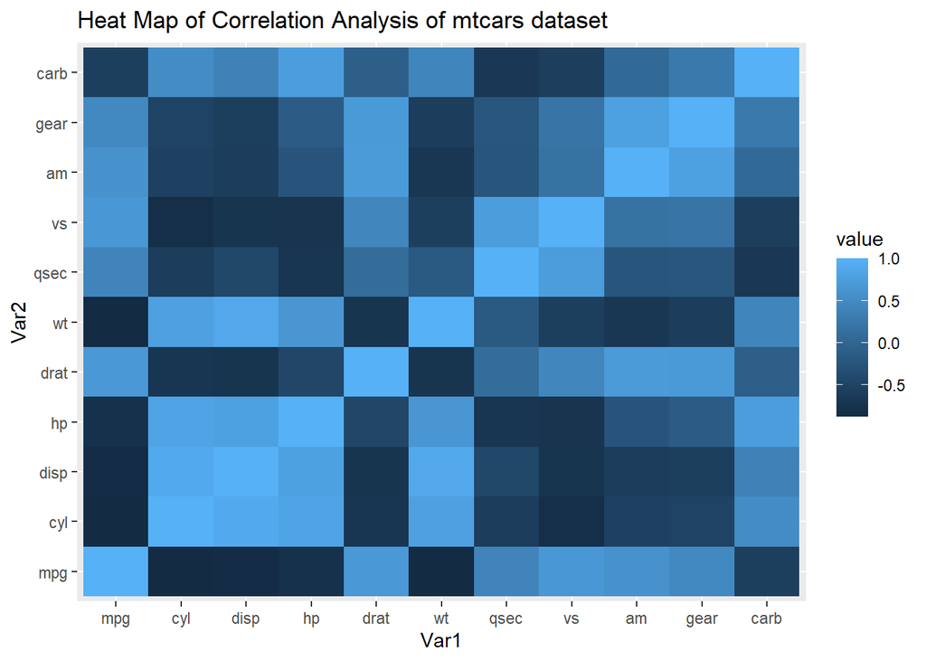

```r
# First we have a heat map
ggplot(meltCar, aes(Var1, Var2, fill = value))+
  geom_tile()+
  ggtitle("Heat Map of Correlation Analysis of mtcars dataset")
```

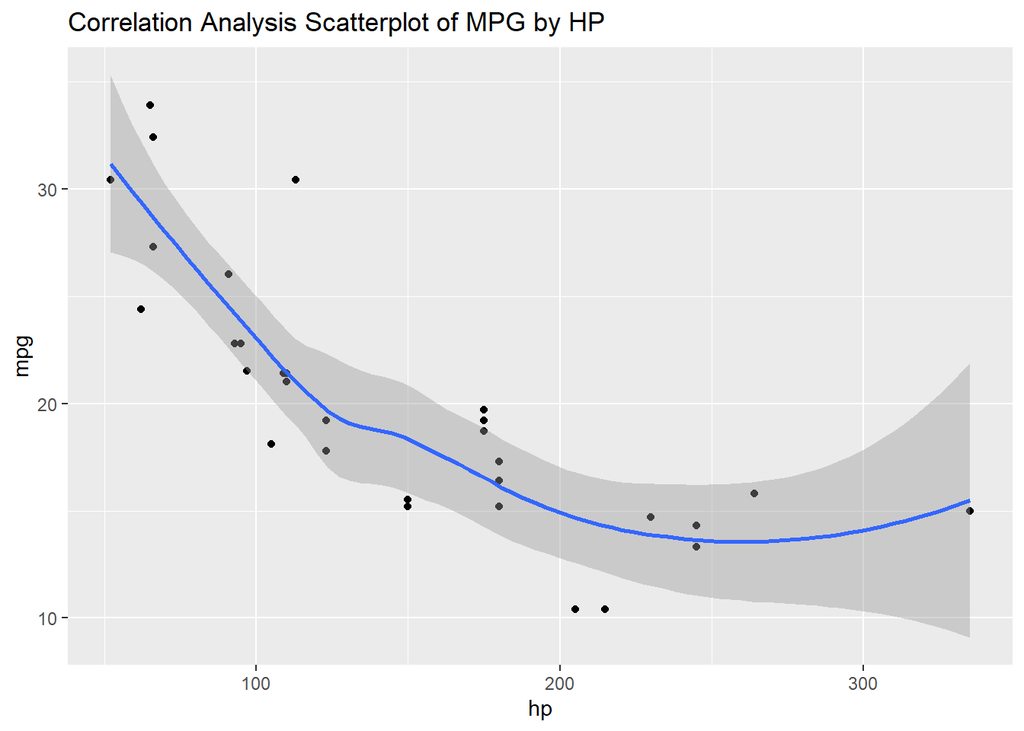

```r
# scatter plots
ggplot(carData, aes(hp, mpg))+
  geom_point()+
  geom_smooth()+
  ggtitle("Correlation Analysis Scatterplot of MPG by HP")
```

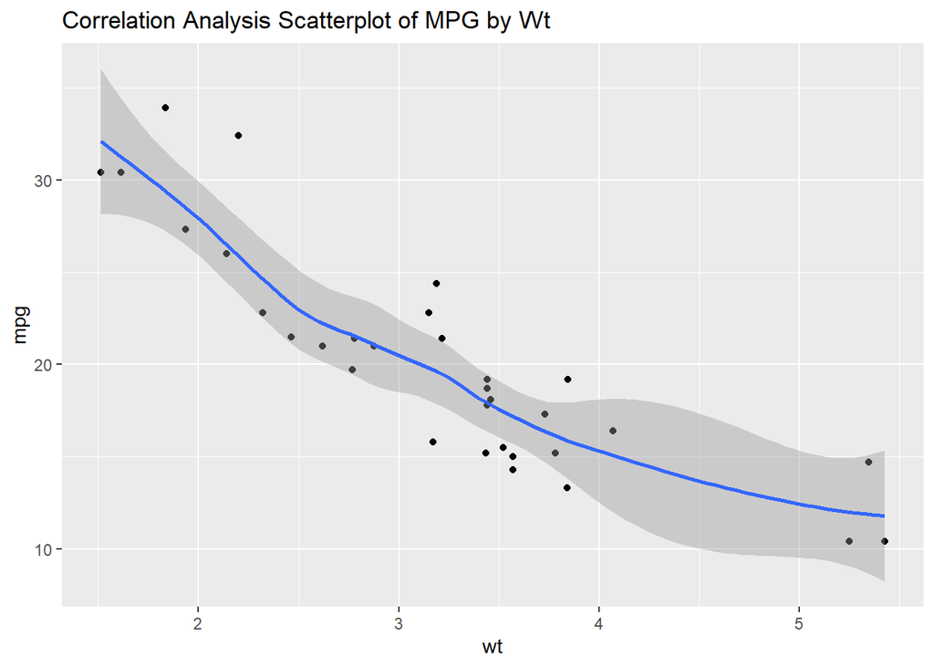

```r
ggplot(carData, aes(wt, mpg))+
  geom_point()+
  geom_smooth()+
  ggtitle("Correlation Analysis Scatterplot of MPG by Wt")
```